# Cloud Computing - Week 2 Lab session

#### Author: Dr. Martin O’Connor

## Introduction

The purpose of this week’s lab activities is to give you practical exposure to virtualization technology using the Oracle VM VirtualBox Manager, and to illustrate resource optimization by running multiple operating systems concurrently on the same physical host.

**Important**

This week’s lab session must be completed using the Desktop PCs provided in the lab because all of the necessary prerequisites are already installed and correctly configured. This lab session has been verified to work fully and completely on the Desktop PCs provided. The instructions must be followed as provided, including downloading the precise version of any software or file specified.

If a student chooses to use their own laptop, they cannot expect the assistance of the lab tutors, as there are many things that can go wrong, specific to each student’s laptop, and the valuable lab time would be frittered away dealing with these issues.

However, **after having first successfully and completed fully all the tasks in this lab session**, students are then strongly encouraged to download and install on to their laptops, both the [Oracle VirtualBox Manager](https://www.virtualbox.org/wiki/Downloads) and the latest version of the [Ubuntu virtual machine](https://ubuntu.com/download/desktop) if their laptop supports it.

These are the specific prerequisites necessary to complete this lab activity successfully as designed by the lecturer:

1. The host Operating System must be Windows 11.
2. Virtualization must be enabled in the BIOS.
3. The Oracle VirtualBox Manager must already be installed.
4. The Computer must have a minimum of 16GB RAM, 2 CPUs and 10 GB of free Hard disk space.

In this week’s lab session, you will learn (and implement):

- How to create a virtual machine that emulates a physical computer with all the necessary component parts.
- How to place a virtual CD (in the form of an ISO file) in to a virtual CDROM in a virtual computer.
- How to install a complete Linux operating system onto a virtual hard drive in a virtual machine from a virtual CD.
- How to create a shared folder to share files between the physical host computer and the guest Linux OS in the virtual computer.
- How to install the Guest Additions software to enable richer functionality and seamless integration between the virtual computer and the physical host computer.
- How to export a virtual machine as a portable OVA file that may be put on a USB key and brought anywhere.
- How to import a virtual machine from a portable OVA file.
- How to quickly add a virtual machine in under one second (so that when you are asked to demonstrate a project using virtual machines, you can get your demonstration up and running very quickly without delay).

  You may not complete all the lab exercises this week. However, all students are expected to complete the lab exercises before next week’s lab.

  **Tip**

  A note on interpreting the various instructions that will follow.

  For example, When you are asked to:

  > From the menu bar, select Machine | New

  This may be understood as:

  from the menu bar: first select *Machine*. Then, when a context menu appears, select *New*.

  A second example:

  > Within the Oracle VM VirtualBox Manager, right-click on the Ubuntu virtual machine and select Settings | Shared Folders (in the left-hand-side column).

  This may be understood as:

  Within the Oracle VM VirtualBox Manager:
  - first right-click with the mouse on the *Ubuntu virtual machine*.
  - Then, in the context menu that appears, select *Settings*.
  - Then, in the dialog box that appears, select *Shared Folders* (in the left-hand-side column).

## Task 1 – Create a New Virtual Machine configured to run Ubuntu Linux.

Download the Ubuntu 32-bit operating system (i386) desktop ISO image file to your `Downloads` folder from:  
https://releases.ubuntu.com/16.04/ubuntu-16.04.6-desktop-i386.iso

We are using the *32-bit PC (i386) desktop image* because it guarantees the best compatibility with the many different computing devices used by students. The downloaded file should have the following name (or something similar):  
`ubuntu-16.04.6-desktop-i386.iso`

1. Run the Oracle VM VirtualBox Manager and create a new Virtual Machine.
   1. From the menu, select *Machine* | *New*.
   2. Under Virtual Machine Name and Operating System Window:
      1. Set Name to *Ubuntu*
      2. Leave the folder unchanged (with the default settings). It should look something like `C:\Users\Martin.OConnor\VirtualBox VMs`
      3. Leave the ISO Image as `<not selected>`
      4. Set type to *Linux*
      5. Set Version to *Ubuntu (32-bit)*
      6. Select Next
   3. Under the Hardware Window:
      1. If you have 16GB (or more) of RAM on your laptop/desktop, then select 8192MB of base memory.

         If you have between 8GB and 16GB of RAM on your laptop/desktop, then select a 6144MB of base memory. *Note: this lab will run either very slowly with just 8GB Ram, or not at all*.

         If you have less than 8GB of RAM on your laptop/desktop, then this lab activity will not work.
      2. If you have more than two processors, select 2 CPUs.

         If you have two or less processors, select 1 CPU. *Note: this lab will run either very slowly with just 1 cpu, or not at all*.
      3. Select Next
   4. Under the Virtual Hard Disk Window:
      1. Check the label: Create a virtual hard disk now.
      2. Enter *25GB* as the disk size.
      3. Do NOT check the box *Pre-allocatte Full Size*.
      4. Select Next.
   5. Under the Summary Window:
      1. Review the details.
      2. Select Finish.
   6. A new virtual machine should appear in the left-hand column  
      of the Oracle VM VirtualBox Manager Window, as shown below.

[figure not shown]

   7. In the Oracle VM VirtualBox Manager Window, select the  
      Ubuntu virtual machine by left-clicking on it.
      1. Select the *Settings* button on the menu bar.
      2. Under Ubuntu Settings, on the left-hand side, select  
         *System*.
         1. Under the Motherboard tab, check the box  
            *“Enable I/O APIC*”.
         2. Under the Processor tab, Increase the processor  
            count from 1 to 2, if your have more than 2 CPUs.
         3. On the left-hand side, select *Display*.
         4. **This step is very important**

            Under the Screen tab, increase Video Memory from 16MB to 128MB.
      3. Verify that the bottom of the Ubuntu Settings Windows DOES NOT state “*Invalid Settings Detected*” as show below.

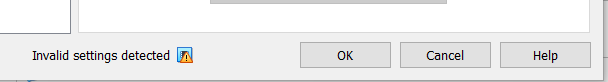

         If it states invalid settings, fix the problem or ask the  
         lab tutor.
      4. Select OK.

## Task 2 – Configure the Virtual Machine to boot from a virtual Linux CD

   This will allow you to boot the Virtual Machine with the Ubuntu installation CD in the Virtual CDROM.
   1. In the Oracle VM VirtualBox Manager Window, select the Ubuntu virtual machine by left clicking on it.
   2. Select the *Settings* button on the menu bar.
   3. Under Ubuntu Settings window, on the left-hand side,  
      select *Storage*
   4. Immediately to the right of *Controller: IDE*, there should be a circular disk with a plus symbol on it.

      Select the circular disk icon with a plus on it (not the square icon with a plus on it).
   5. Under the Ubuntu Optical Disk Selector Window,  
      select the option *Add*
   6. Navigate to the folder where you downloaded the `ubuntu-16.04.6-desktop-i386.iso` file and select it.
   7. Select *Open*
   8. Under the Ubuntu Optical Disk Selector Window,  
      select the option *Choose*
   9. Under Ubuntu Settings window,  
      select *OK* (to close the Window)

[figure not shown]

      Ubuntu Settings Window

## Task 3 – Create and configure a shared-folder between the Host machine and the guest Virtual Machine.

3. Configure the Ubuntu Virtual Machine to have a shared folder in `c:\temp\sharedfolder` called `sharedfolder`.
   1. Using the Windows File Manager, create a folder path called `c:\temp\sharedfolder` if it does not already exist.
   2. Within the Oracle VM VirtualBox Manager, right-click on the *Ubuntu* virtual machine and select Settings | Shared Folders (in the left-hand-side column)
   3. On the right-hand-side of the Shared Folders window, there should be a folder icon with a plus symbol on it.

      Select the folder icon with a plus symbol on it.
      1. In the Folder path, type (exactly as shown):  
         `c:\temp\sharedfolder\`
      2. In the folder name, type (exactly as shown):  
         `sharedfolder`
      3. Check the box: Auto-mount
      4. Mount Point: leave empty.
   4. Select Ok (to add the shared folder)
   5. Select Ok (to close the Shared Folders Window)

      We have just informed the host machine of a shared folder that the virtual machine may access. We have also ensured that the virtual *Ubuntu* Linux machine will auto-mount the shared folder when the virtual machine starts.

[figure not shown]

## Video Demonstration

The Lecturer has made available an 8-minute YouTube video providing a detailed explanation of the various virtualised components that make up a virtual machine.

Before watching the video, please note: If you have bluetooth ear buds (or a headset), you may use them. However, the volume on everyones PC and laptop must be set to zero (silence), so as not to disturb your classmates or lab tutor. You may enable the subtitles to follow along with the video if you do not have a headset.

The video was recorded several years ago, thus some of the screens may look slightly different now.

After watching the video, please come back and complete the remaining lab activities.

Please watch the [VirtualBox Tutorial 06 - VM Configuration Settings Explained](https://youtu.be/WEa8AHVAffE) video now.

## Task 4 – Install the Ubuntu Linux Operating System as a guest Virtual Machine

4. Within the Oracle VM VirtualBox Manager, ensure the Ubuntu virtual machine is selected by left-clicking on it. Then select the green arrow labelled `Start`.
   1. When the virtual machine starts, several warning messages may appear. Read them first by left clicking on them. When you are finished reading them, dismiss them by clicking on the red X icon.

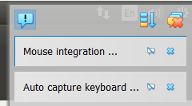

   2. Read and understand the note: Mouse Integration

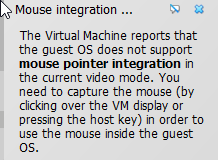

   3. Read and understand the note: Auto Capture Keyboard

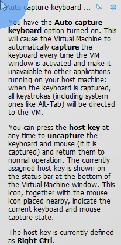

      Don’t worry, this message simply informs you that the mouse is *captured* inside the virtual machine windows.

      To permit your mouse pointer to access your Host OS (i.e.: Windows 11), simply press the `Right-Ctrl` key, and this will free the mouse pointer.
   4. Select ‘Install Ubuntu’
   5. Check the box *Download updates*.

      Check the box *Install third party software*.

      Select *Continue*
   6. Select the option *Erase disk and install Ubuntu*

      Select *Install now*.

      Note: This will erase the virtual disk in the virtual guest computer (not your local hard disk).
   7. Agree to *Write the changes to* *disk* by selecting continue.
   8. Select *Dublin* as your Timezone and continue.
   9. Select *Irish keyboard layout* when prompted and continue.
   10. Under Who are you?
       1. Enter your full name
       2. Enter `pluto` as your computer name
       3. Enter `testuser` as the username.
       4. Enter `testpass01` as password.
       5. Check the option *Require my password to log in*
       6. Check the option to encrypt the home directory.
       7. Select *Continue*

          …The installation begins…It may take a while…
   11. When informed that the Installation is complete,  
       select Restart Now.
   12. When prompted to remove the installation medium, verify the Ubuntu CD has been automatically removed from the virtual CDROM.
       1. From the menu bar, select Devices | Optical Drives | IDE Primary Master | Remove Disk from Virtual Drive

          The *Remove Disk from Virtual Drive* option should be grayed out. If not, select this option to eject the CD.

          Select *Force unmount* if necessary.
       2. Press enter to reboot the virtual machine.
   13. The Virtual machine will reboot, and boot into the Ubuntu OS that we have just installed.
   14. Logon using the password provided in step 4.10.4.
   15. Congratulations, you have successfully installed and configured a Virtual Machine running the Ubuntu OS.

   **The Login screen that appears on first boot after successfully installing Ubuntu OS.**

[figure not shown]

   **The desktop displayed after first login.**

[figure not shown]

   16. To run the Linux command line terminal, press `Ctrl-Alt-T`

       You can now install whatever packages you want and run whatever commands you want. You have your very own personal Linux virtual machine.
   17. To safely stop the Ubuntu Virtual Machine at any time:  
       from the menu bar, select File | Close | Power off the machine.

## Task 5 – Install the Oracle VM Guest Additions extension

5. The Guest Additions extension is designed to be installed inside a virtual machine after the guest operating system has been installed. It consists of device drivers and system applications that optimize the guest operating system for better performance and usability.
   1. From the *Ubuntu [Running] Oracle VM Virtualbox* Window menu, select Devices | Install Guest Additions CD Image…

      This will effectively place a CDROM into the Virtualbox CD Drive.
   2. Select *run* when prompted.
   3. A command line terminal will appear. You will be prompted to enter your password. Please enter your password and select *authenticate*
   4. The Guest Additions modules will be installed. This may take a few minutes.

      When prompted, press *return* to exit the command terminal and complete the installation.
   5. Close down the Ubuntu Virtual Machine.

      The benefits of the Guest Additions extension include:

      If you maximise the running Ubuntu Virtual Machine Window, it should correctly resize the window.

      Furthermore, the mouse is no longer captured – you can move the mouse between the Virtual Machine and the Host machine freely without any problems.

## Task 6 – Export your Virtual Machine to an OVA file so that you may put it on your USB key and use it anywhere.

In Oracle Virtualbox Manager, when you create a new virtual machine, the default file format has the extension `.vdi`. There are also options to use the file extensions `.vmdk` (for VmWare), or `.vhd` (for VirtualPC) format.

OVF, also known as Open Virtualization Format, is one of the ways to standardize virtual appliances so they can be imported and used in different virtualization software - that is, to make them portable across different computers. A virtual appliance in the OVF format has the file extension `.ova` and is in effect a type of container file (like `.zip`). It contains within it, a series of files. The `.ova` file extension format is merely a single file distribution of the OVF compatible virtual machine, stored in the `.tar` format.

6. To export a `.vdi` file (the default format for an Oracle Virtualbox hard disk image) to a portable OVA file format so that you may run it on another computer, first verify the virtual machine you want to export is not running.
   1. Run the Oracle VM VirtualBox Manager and verify the status of Ubuntu is ’*Powered Off’*.

      If it is not powered off, do so now: From the *Ubuntu [Running] Oracle VM Virtualbox* Window menu, select File | Close | Power off the machine | Ok.
   2. From the Oracle VM VirtualBox Manager Menu bar:

      select File | Export Appliance
   3. In the *Export Virtual Appliance* dialog box, Select the Virtual machine you want to export:

      In this case, select *Ubuntu*.

      Then select *Next*
   4. Next, under Format Settings, select the destination folder and choose a filename for the new OVA file.
      1. Select format as *Open Virtualization Format 1.0*
      2. Choose the following filename `c:\temp\Ubuntu.ova`. Overwrite it if it already exists.
      3. Check the box ’*Write Manifest File’*.

         The manifest will contain all of the VirtualBox settings for the virtual machine we are exporting.
      4. select *Next*
      5. Do not check the box *‘Include ISO image files’*
   5. Under Appliance Settings, leave the default settings as they are and select ’*Finish’*.

      This operation may take 10 - 15 minutes (or longer) to complete.
   6. Congratulations. You have successfully created a portable image of your virtual machine that may be imported and run on another computer. I suggest you copy it to your external (USB) drive, if you have one.

## Task 7 – Import an existing Virtual Machine (OVA file).

You may import an existing Virtual Machine (in the format of an `.ova` file) that you obtained from another computer into the Oracle VM VirtualBox Manager. The Virtual Machine OVA file may be stored on a USB Key.

To perform this step in the lab, please ensure you have first fully removed the Ubuntu Virtual machine from the Oracle VirtualBox Manager.

To fully remove the *Ubuntu Virtual machine*: Within the Oracle VM VirtualBox Manager, right-click on the Ubuntu virtual machine | select *Remove* | Select *Delete all files*

Now proceed with importing the portable `Ubuntu.ova` image we created earlier.

7. Start the application **Oracle VM VirtualBox Manager**.
   1. Import the Ubuntu.ova file:
      1. From the menu, select File | Import Appliance.
      2. Click on the folder icon with the green up-arrow.
      3. Navigate to `c:\temp` and select the `Ubuntu.ova` file.
      4. Click Open.
      5. Select next.
      6. In the ‘Appliance settings’ dialog, check the box  
         *Generate the MAC address of all network cards*
      7. Select Finish.

         This may take several minutes.
   2. Congratulations, you have successfully imported a Ubuntu Linux Virtual Machine Image.

## Task 8 – Backup an existing Virtual Machine (directly)

When you import an existing Virtual Machine (in the format of an `.ova` file) into the Oracle VM VirtualBox Manager, it essentially unpacks (unzips) the various files that make up the Virtual Machine and places them into a specific folder (default machine folder) on the hard drive. This may take a while, depending on how old or new your computer is.

One could instead choose to store the unpacked files directly on a fast external USB drive, and simply *add* the virtual machine directly from the drive instead of *importing* it.

The advantages are that the operation to add a machine is very quick - less than one second, and any changes made to the virtual machine are automatically saved on the external drive.

The potential disadvantage is that the performance of the virtual machine may be impacted if the external drive is slow.

We will now determine the location of the *default machine folder* which contains your Virtual Machine(s) and then copy the Ubuntu virtual machine to your external drive.

8. Start the application **Oracle VM VirtualBox Manager**.
   1. From the menu bar, select File | Preferences | General | Default Machine Folder.

      Make a note of the *default machine folder*. It should look something like: `C:\Users\Martin.OConnor\VirtualBox VMs`

      **Important**

      To complete this task, you require an external hard drive (or fast USB Key) with at least 4GB of free disk space.

      If you do not have it, skip the remainder of this task.
   2. Using Windows File Manager, from within the default machine folder, copy the `Ubuntu` subfolder to your external hard drive.
   3. Congratulations, you have successfully backed up your Ubuntu Linux Virtual Machine directly to your external hard drive.

## Task 9 – Add an existing Virtual Machine directly from your external hard drive.

Once again, to perform this step in the lab, please ensure you have first fully removed the Ubuntu Virtual machine from the Oracle VirtualBox Manager.

**Important**

To complete this task, you require an external hard drive (or fast USB Key) with at least 4GB of free disk space.

If you do not have it, skip the remainder of this task.

To fully remove the *Ubuntu Virtual machine*: Within the Oracle VM VirtualBox Manager, right-click on the Ubuntu virtual machine | select *Remove* | Select *Delete all files*

Now proceed with adding the existing Virtual Machine directly from your external hard drive.

9. Start the application **Oracle VM VirtualBox Manager**.
   1. Add the Ubuntu Linux Virtual Machine
      1. From the menu, select Machine | Add
      2. Navigate to the folder containing the unpacked virtual machine image on your external hard drive and select the *Ubuntu.vbox* file.

         For example, it may be located at `d:\ubuntu\Ubuntu.vbox`
      3. Click Open.
   2. Congratulations, you have successfully added a Ubuntu Linux Virtual Machine Image directly from your external hard drive.

**NoteSharedfolder functionality**

I am aware that a demonstration of sharing files between the Guest OS and the Host OS using the `sharedfolder` functionality was not provided in this lab session.

Although we installed the *Guest Additions* extension in the Guest OS (Ubuntu), we are also required to install a separate *[Virtualbox Extensions Pack](https://www.virtualbox.org/wiki/Downloads)* in the Oracle VirtualBox Manager running on the Host Computer, in order to avail of the `sharedfolder` functionality. Be aware the version of the *Virtualbox Extensions Pack* to be installed must be identical to the version of the Oracle VirtualBox Manager already installed on the Host Windows 11 operating system.

However, the *Virtualbox Extensions Pack* installation requires `Adminstrator` privileges on the host desktop PCs in the labs, which neither students nor the lecturers have. Thus, the demonstration was omitted from this lab session.

For those students who would like to implement the `sharedfolder` functionality on their own laptops/desktops, I have made available a [6-minute video](https://www.youtube.com/watch?v=9-teQnZ8LEY) illustrating step-by-step how to implemented it and I demonstrate the `sharedfolder` in action.